# Retrieve Data from 2 or More Tables

Author

Jianyuan(Andy) Hu

Published

October 12, 2024

# Reference

This document is based on Murach, J. (2023). Murach’s MySQL (4th Edition).

Default database in this document is “ap”.

Other databases included in the simulation MySQL server:

- om
- ex

# Join Logic

Illustration of common join types:

- inner join
- left join
- right join
- outer join
- union (“stacking”)
- full (outer) join

*Note: full join is not available for all SQL dialects. It is a combination of left join + union + right join*

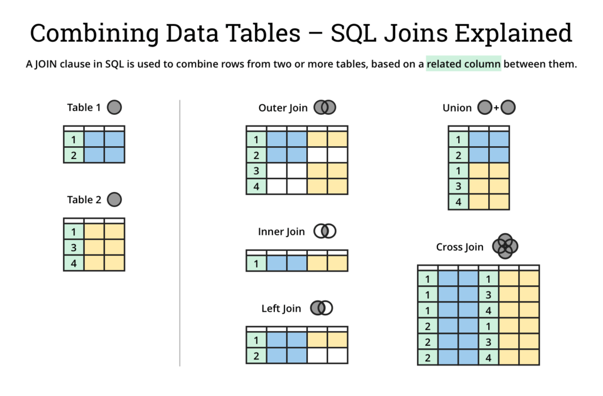

[Source](https://www.atlassian.com/data/sql/sql-join-types-explained-visually)

Some other join types:

- (Left) Semi-Join: returns only rows in the left table that *have matching rows* in the right table
- (Left) Anti-Join: returns rows in the left table that *have no matching rows* in the right table

**Note:**

- Semi-join and Anti-join don’t bring any additional fields from other tables.
- Semi-join and Anti-join are not covered in details here, because MySQL doesn’t have native implementation for these join types.

# Inner Join

tables overview

```sql
SELECT *
FROM invoices
ORDER BY invoice_number
LIMIT 10
```

10 records

| invoice_id | vendor_id | invoice_number | invoice_date | invoice_total | payment_total | credit_total | terms_id | invoice_due_date | payment_date |
| --- | --- | --- | --- | --- | --- | --- | --- | --- | --- |
| 39 | 110 | 0-2058 | 2022-05-28 | 37966.19 | 37966.19 | 0.00 | 3 | 2022-06-27 | 2022-06-30 |
| 106 | 110 | 0-2060 | 2022-07-24 | 23517.58 | 21221.63 | 2295.95 | 3 | 2022-08-23 | 2022-08-27 |
| 112 | 110 | 0-2436 | 2022-07-31 | 10976.06 | 0.00 | 0.00 | 3 | 2022-08-30 | NA |
| 30 | 123 | 1-200-5164 | 2022-05-20 | 63.40 | 63.40 | 0.00 | 3 | 2022-06-19 | 2022-06-24 |
| 48 | 123 | 1-202-2978 | 2022-06-03 | 33.00 | 33.00 | 0.00 | 3 | 2022-07-03 | 2022-07-05 |
| 21 | 119 | 10843 | 2022-05-11 | 4901.26 | 4901.26 | 0.00 | 2 | 2022-05-31 | 2022-05-29 |
| 74 | 102 | 109596 | 2022-06-24 | 41.80 | 41.80 | 0.00 | 4 | 2022-08-03 | 2022-08-04 |
| 53 | 95 | 111-92R-10092 | 2022-06-09 | 46.21 | 46.21 | 0.00 | 2 | 2022-06-29 | 2022-07-02 |
| 83 | 95 | 111-92R-10093 | 2022-07-06 | 39.77 | 39.77 | 0.00 | 2 | 2022-07-26 | 2022-07-22 |
| 44 | 95 | 111-92R-10094 | 2022-06-01 | 19.67 | 19.67 | 0.00 | 2 | 2022-06-21 | 2022-06-24 |

```sql
SELECT *
FROM vendors
ORDER BY vendor_name
LIMIT 10
```

10 records

| vendor_id | vendor_name | vendor_address1 | vendor_address2 | vendor_city | vendor_state | vendor_zip_code | vendor_phone | vendor_contact_last_name | vendor_contact_first_name | default_terms_id | default_account_number |
| --- | --- | --- | --- | --- | --- | --- | --- | --- | --- | --- | --- |
| 94 | Abbey Office Furnishings | 4150 W Shaw Ave | NA | Fresno | CA | 93722 | (559) 555-8300 | Francis | Kyra | 2 | 150 |
| 61 | American Booksellers Assoc | 828 S Broadway | NA | Tarrytown | NY | 10591 | (800) 555-0037 | Angelica | Nashalie | 3 | 574 |
| 98 | American Express | Box 0001 | NA | Los Angeles | CA | 90096 | (800) 555-3344 | Story | Kirsten | 2 | 160 |
| 15 | ASC Signs | 1528 N Sierra Vista | NA | Fresno | CA | 93703 | NA | Darien | Elisabeth | 1 | 546 |
| 66 | Ascom Hasler Mailing Systems | PO Box 895 | NA | Shelton | CT | 06484 | NA | Lewis | Darnell | 3 | 532 |
| 93 | AT&T | PO Box 78225 | NA | Phoenix | AZ | 85062 | NA | Wesley | Alisha | 3 | 522 |
| 52 | Aztek Label | Accounts Payable | 1150 N Tustin Ave | Anaheim | CA | 92807 | (714) 555-9000 | Griffin | Brian | 3 | 551 |
| 47 | Baker & Taylor Books | Five Lakepointe Plaza, Ste 500 | 2709 Water Ridge Parkway | Charlotte | NC | 28217 | (704) 555-3500 | Bernardo | Brittnee | 3 | 572 |
| 99 | Bertelsmann Industry Svcs. Inc | 28210 N Avenue Stanford | NA | Valencia | CA | 91355 | (805) 555-0584 | Potter | Lance | 3 | 400 |
| 8 | BFI Industries | PO Box 9369 | NA | Fresno | CA | 93792 | (559) 555-1551 | Kaleigh | Erick | 3 | 521 |

Explicit (INNER JOIN)

```sql
SELECT invoice_number, vendor_name
FROM vendors INNER JOIN invoices
    ON vendors.vendor_id = invoices.vendor_id
ORDER BY invoice_number
LIMIT 10
```

10 records

| invoice_number | vendor_name |
| --- | --- |
| 0-2058 | Malloy Lithographing Inc |
| 0-2060 | Malloy Lithographing Inc |
| 0-2436 | Malloy Lithographing Inc |
| 1-200-5164 | Federal Express Corporation |
| 1-202-2978 | Federal Express Corporation |
| 10843 | Yesmed, Inc |
| 109596 | Coffee Break Service |
| 111-92R-10092 | Pacific Bell |
| 111-92R-10093 | Pacific Bell |
| 111-92R-10094 | Pacific Bell |

Compare to the above:

- table aliases now used
- just JOIN, instead of full INNER JOIN, now used

```sql
SELECT invoice_number, vendor_name, invoice_due_date,
    invoice_total - payment_total - credit_total
    AS balance_due
FROM vendors v JOIN invoices i
    ON v.vendor_id = i.vendor_id
WHERE invoice_total - payment_total - credit_total > 0
ORDER BY invoice_due_date DESC
```

11 records

| invoice_number | vendor_name | invoice_due_date | balance_due |
| --- | --- | --- | --- |
| 547480102 | Blue Cross | 2022-08-31 | 224.00 |
| 0-2436 | Malloy Lithographing Inc | 2022-08-30 | 10976.06 |
| 9982771 | Ford Motor Credit Company | 2022-08-23 | 503.20 |
| P-0608 | Malloy Lithographing Inc | 2022-08-22 | 19351.18 |
| 263253270 | Federal Express Corporation | 2022-08-21 | 67.92 |
| 263253273 | Federal Express Corporation | 2022-08-21 | 30.75 |
| 263253268 | Federal Express Corporation | 2022-08-20 | 59.97 |
| 963253264 | Federal Express Corporation | 2022-08-17 | 52.25 |
| 134116 | Cardinal Business Media, Inc. | 2022-08-17 | 90.36 |
| 31361833 | Ingram | 2022-08-10 | 579.42 |
| 39104 | Data Reproductions Corp | 2022-08-09 | 85.31 |

Compare to the above:

- alias now refers to a table from a different database

```sql
SELECT vendor_name, customer_last_name,
    customer_first_name, vendor_state AS state,
    vendor_city AS city
FROM vendors v
    JOIN om.customers c
    ON v.vendor_zip_code = c.customer_zip
ORDER BY state, city
```

Displaying records 1 - 15

| vendor_name | customer_last_name | customer_first_name | state | city |
| --- | --- | --- | --- | --- |
| Wells Fargo Bank | Marissa | Kyle | AZ | Phoenix |
| Aztek Label | Irvin | Ania | CA | Anaheim |
| Zylka Design | Neftaly | Thalia | CA | Fresno |
| Lou Gentile’s Flower Basket | Damien | Deborah | CA | Fresno |
| Costco | Holbrooke | Rashad | CA | Fresno |
| Costco | Neftaly | Thalia | CA | Fresno |
| Shields Design | Damien | Deborah | CA | Fresno |
| Wakefield Co | Neftaly | Thalia | CA | Fresno |
| Wakefield Co | Holbrooke | Rashad | CA | Fresno |
| Gary McKeighan Insurance | Holbrooke | Rashad | CA | Fresno |
| Gary McKeighan Insurance | Neftaly | Thalia | CA | Fresno |
| Digital Dreamworks | Holbrooke | Rashad | CA | Fresno |
| Digital Dreamworks | Neftaly | Thalia | CA | Fresno |
| Gostanian General Building | Holbrooke | Rashad | CA | Fresno |
| Gostanian General Building | Neftaly | Thalia | CA | Fresno |

Implicit joins (WHERE clause instead of ON clause)

```sql
SELECT invoice_number, vendor_name
FROM vendors v, invoices i
WHERE v.vendor_id = i.vendor_id
ORDER BY invoice_number
LIMIT 10
```

10 records

| invoice_number | vendor_name |
| --- | --- |
| 0-2058 | Malloy Lithographing Inc |
| 0-2060 | Malloy Lithographing Inc |
| 0-2436 | Malloy Lithographing Inc |
| 1-200-5164 | Federal Express Corporation |
| 1-202-2978 | Federal Express Corporation |
| 10843 | Yesmed, Inc |
| 109596 | Coffee Break Service |
| 111-92R-10092 | Pacific Bell |
| 111-92R-10093 | Pacific Bell |
| 111-92R-10094 | Pacific Bell |

Implicit joins with (USING keyword), results identical as the above.

```sql
SELECT invoice_number, vendor_name
FROM vendors
    JOIN invoices USING (vendor_id)
ORDER BY invoice_number
```

Displaying records 1 - 15

| invoice_number | vendor_name |
| --- | --- |
| 0-2058 | Malloy Lithographing Inc |
| 0-2060 | Malloy Lithographing Inc |
| 0-2436 | Malloy Lithographing Inc |
| 1-200-5164 | Federal Express Corporation |
| 1-202-2978 | Federal Express Corporation |
| 10843 | Yesmed, Inc |
| 109596 | Coffee Break Service |
| 111-92R-10092 | Pacific Bell |
| 111-92R-10093 | Pacific Bell |
| 111-92R-10094 | Pacific Bell |
| 111-92R-10095 | Pacific Bell |
| 111-92R-10096 | Pacific Bell |
| 111-92R-10097 | Pacific Bell |
| 111897 | Suburban Propane |
| 121897 | Gostanian General Building |

- use inner join
- use columns of same names from the tables
- MySQL, yes, but not for all SQL dialects

```sql
SELECT invoice_number, vendor_name
FROM vendors
    NATURAL JOIN invoices
ORDER BY invoice_number
```

Displaying records 1 - 15

| invoice_number | vendor_name |
| --- | --- |
| 0-2058 | Malloy Lithographing Inc |
| 0-2060 | Malloy Lithographing Inc |
| 0-2436 | Malloy Lithographing Inc |
| 1-200-5164 | Federal Express Corporation |
| 1-202-2978 | Federal Express Corporation |
| 10843 | Yesmed, Inc |
| 109596 | Coffee Break Service |
| 111-92R-10092 | Pacific Bell |
| 111-92R-10093 | Pacific Bell |
| 111-92R-10094 | Pacific Bell |
| 111-92R-10095 | Pacific Bell |
| 111-92R-10096 | Pacific Bell |
| 111-92R-10097 | Pacific Bell |
| 111897 | Suburban Propane |
| 121897 | Gostanian General Building |

Join on multiple columns (“combo join”, join based on combination of columns/keys)

table customers overview:

```sql
SELECT *
FROM om.customers
```

Displaying records 1 - 15

| customer_id | customer_first_name | customer_last_name | customer_address | customer_city | customer_state | customer_zip | customer_phone | customer_fax |
| --- | --- | --- | --- | --- | --- | --- | --- | --- |
| 1 | Korah | Blanca | 1555 W Lane Ave | Columbus | OH | 43221 | 6145554435 | 6145553928 |
| 2 | Yash | Randall | 11 E Rancho Madera Rd | Madison | WI | 53707 | 2095551205 | 2095552262 |
| 3 | Johnathon | Millerton | 60 Madison Ave | New York | NY | 10010 | 2125554800 | NULL |
| 4 | Mikayla | Damion | 2021 K Street Nw | Washington | DC | 20006 | 2025555561 | NULL |
| 5 | Kendall | Mayte | 4775 E Miami River Rd | Cleves | OH | 45002 | 5135553043 | NULL |
| 6 | Kaitlin | Hostlery | 3250 Spring Grove Ave | Cincinnati | OH | 45225 | 8005551957 | 8005552826 |
| 7 | Derek | Chaddick | 9022 E Merchant Wy | Fairfield | IA | 52556 | 5155556130 | NULL |
| 8 | Deborah | Damien | 415 E Olive Ave | Fresno | CA | 93728 | 5595558060 | NULL |
| 9 | Karina | Lacy | 882 W Easton Wy | Los Angeles | CA | 90084 | 8005557000 | NULL |
| 10 | Kurt | Nickalus | 28210 N Avenue Stanford | Valencia | CA | 91355 | 8055550584 | 055556689 |
| 11 | Kelsey | Eulalia | 7833 N Ridge Rd | Sacramento | CA | 95887 | 2095557500 | 2095551302 |
| 12 | Anders | Rohansen | 12345 E 67th Ave NW | Takoma Park | MD | 24512 | 3385556772 | NULL |
| 13 | Thalia | Neftaly | 2508 W Shaw Ave | Fresno | CA | 93711 | 5595556245 | NULL |
| 14 | Gonzalo | Keeton | 12 Daniel Road | Fairfield | NJ | 07004 | 2015559742 | NULL |
| 15 | Ania | Irvin | 1099 N Farcourt St | Orange | CA | 92807 | 7145559000 | NULL |

```sql
SELECT *
FROM ex.employees
```

9 records

| employee_id | last_name | first_name | department_number | manager_id |
| --- | --- | --- | --- | --- |
| 1 | Smith | Cindy | 2 | NA |
| 2 | Jones | Elmer | 4 | 1 |
| 3 | Simonian | Ralph | 2 | 2 |
| 4 | Hernandez | Olivia | 1 | 9 |
| 5 | Aaronsen | Robert | 2 | 4 |
| 6 | Watson | Denise | 6 | 8 |
| 7 | Hardy | Thomas | 5 | 2 |
| 8 | O’Leary | Rhea | 4 | 9 |
| 9 | Locario | Paulo | 6 | 1 |

- “Are there any customers and employees with the same first and last name?”

```sql
SELECT customer_first_name, customer_last_name
FROM om.customers c INNER JOIN ex.employees e
    ON c.customer_first_name = e.first_name
   AND c.customer_last_name = e.last_name
```

0 records

| customer_first_name | customer_last_name |
| --- | --- |

## A Somewhat Special Example - Self Join

To make self-join work:

- must use alias to avoid recycling same table reference
- “In those cities where more than 1 vendors reside, what are the OTHER vendors that in the same city and state?”

Explore the vendor table:

```sql
SELECT *
FROM vendors v1
ORDER BY v1.vendor_id, v1.vendor_state, v1.vendor_city
```

Displaying records 1 - 15

| vendor_id | vendor_name | vendor_address1 | vendor_address2 | vendor_city | vendor_state | vendor_zip_code | vendor_phone | vendor_contact_last_name | vendor_contact_first_name | default_terms_id | default_account_number |
| --- | --- | --- | --- | --- | --- | --- | --- | --- | --- | --- | --- |
| 1 | US Postal Service | Attn: Supt. Window Services | PO Box 7005 | Madison | WI | 53707 | (800) 555-1205 | Alberto | Francesco | 1 | 552 |
| 2 | National Information Data Ctr | PO Box 96621 | NA | Washington | DC | 20120 | (301) 555-8950 | Irvin | Ania | 3 | 540 |
| 3 | Register of Copyrights | Library Of Congress | NA | Washington | DC | 20559 | NA | Liana | Lukas | 3 | 403 |
| 4 | Jobtrak | 1990 Westwood Blvd Ste 260 | NA | Los Angeles | CA | 90025 | (800) 555-8725 | Quinn | Kenzie | 3 | 572 |
| 5 | Newbrige Book Clubs | 3000 Cindel Drive | NA | Washington | NJ | 07882 | (800) 555-9980 | Marks | Michelle | 4 | 394 |
| 6 | California Chamber Of Commerce | 3255 Ramos Cir | NA | Sacramento | CA | 95827 | (916) 555-6670 | Mauro | Anton | 3 | 572 |
| 7 | Towne Advertiser’s Mailing Svcs | Kevin Minder | 3441 W Macarthur Blvd | Santa Ana | CA | 92704 | NA | Maegen | Ted | 3 | 540 |
| 8 | BFI Industries | PO Box 9369 | NA | Fresno | CA | 93792 | (559) 555-1551 | Kaleigh | Erick | 3 | 521 |
| 9 | Pacific Gas & Electric | Box 52001 | NA | San Francisco | CA | 94152 | (800) 555-6081 | Anthoni | Kaitlyn | 3 | 521 |
| 10 | Robbins Mobile Lock And Key | 4669 N Fresno | NA | Fresno | CA | 93726 | (559) 555-9375 | Leigh | Bill | 2 | 523 |
| 11 | Bill Marvin Electric Inc | 4583 E Home | NA | Fresno | CA | 93703 | (559) 555-5106 | Hostlery | Kaitlin | 2 | 523 |
| 12 | City Of Fresno | PO Box 2069 | NA | Fresno | CA | 93718 | (559) 555-9999 | Mayte | Kendall | 3 | 574 |
| 13 | Golden Eagle Insurance Co | PO Box 85826 | NA | San Diego | CA | 92186 | NA | Blanca | Korah | 3 | 590 |
| 14 | Expedata Inc | 4420 N. First Street, Suite 108 | NA | Fresno | CA | 93726 | (559) 555-9586 | Quintin | Marvin | 3 | 589 |
| 15 | ASC Signs | 1528 N Sierra Vista | NA | Fresno | CA | 93703 | NA | Darien | Elisabeth | 1 | 546 |

Step 1: simple self-joining based on city and state of vendor

```sql
SELECT *
FROM vendors v1 INNER JOIN vendors v2
    ON v1.vendor_city = v2.vendor_city AND
       v1.vendor_state = v2.vendor_state
ORDER BY v1.vendor_id, v1.vendor_state, v1.vendor_city
```

Displaying records 1 - 15

| vendor_id | vendor_name | vendor_address1 | vendor_address2 | vendor_city | vendor_state | vendor_zip_code | vendor_phone | vendor_contact_last_name | vendor_contact_first_name | default_terms_id | default_account_number | vendor_id | vendor_name | vendor_address1 | vendor_address2 | vendor_city | vendor_state | vendor_zip_code | vendor_phone | vendor_contact_last_name | vendor_contact_first_name | default_terms_id | default_account_number |
| --- | --- | --- | --- | --- | --- | --- | --- | --- | --- | --- | --- | --- | --- | --- | --- | --- | --- | --- | --- | --- | --- | --- | --- |
| 1 | US Postal Service | Attn: Supt. Window Services | PO Box 7005 | Madison | WI | 53707 | (800) 555-1205 | Alberto | Francesco | 1 | 552 | 1 | US Postal Service | Attn: Supt. Window Services | PO Box 7005 | Madison | WI | 53707 | (800) 555-1205 | Alberto | Francesco | 1 | 552 |
| 2 | National Information Data Ctr | PO Box 96621 | NA | Washington | DC | 20120 | (301) 555-8950 | Irvin | Ania | 3 | 540 | 2 | National Information Data Ctr | PO Box 96621 | NA | Washington | DC | 20120 | (301) 555-8950 | Irvin | Ania | 3 | 540 |
| 2 | National Information Data Ctr | PO Box 96621 | NA | Washington | DC | 20120 | (301) 555-8950 | Irvin | Ania | 3 | 540 | 3 | Register of Copyrights | Library Of Congress | NA | Washington | DC | 20559 | NA | Liana | Lukas | 3 | 403 |
| 2 | National Information Data Ctr | PO Box 96621 | NA | Washington | DC | 20120 | (301) 555-8950 | Irvin | Ania | 3 | 540 | 82 | Reiter’s Scientific & Pro Books | 2021 K Street Nw | NA | Washington | DC | 20006 | (202) 555-5561 | Rodolfo | Carlee | 2 | 572 |
| 3 | Register of Copyrights | Library Of Congress | NA | Washington | DC | 20559 | NA | Liana | Lukas | 3 | 403 | 82 | Reiter’s Scientific & Pro Books | 2021 K Street Nw | NA | Washington | DC | 20006 | (202) 555-5561 | Rodolfo | Carlee | 2 | 572 |
| 3 | Register of Copyrights | Library Of Congress | NA | Washington | DC | 20559 | NA | Liana | Lukas | 3 | 403 | 2 | National Information Data Ctr | PO Box 96621 | NA | Washington | DC | 20120 | (301) 555-8950 | Irvin | Ania | 3 | 540 |
| 3 | Register of Copyrights | Library Of Congress | NA | Washington | DC | 20559 | NA | Liana | Lukas | 3 | 403 | 3 | Register of Copyrights | Library Of Congress | NA | Washington | DC | 20559 | NA | Liana | Lukas | 3 | 403 |
| 4 | Jobtrak | 1990 Westwood Blvd Ste 260 | NA | Los Angeles | CA | 90025 | (800) 555-8725 | Quinn | Kenzie | 3 | 572 | 42 | Opamp Technical Books | 1033 N Sycamore Ave. | NA | Los Angeles | CA | 90038 | (213) 555-4322 | Paris | Gideon | 3 | 572 |
| 4 | Jobtrak | 1990 Westwood Blvd Ste 260 | NA | Los Angeles | CA | 90025 | (800) 555-8725 | Quinn | Kenzie | 3 | 572 | 4 | Jobtrak | 1990 Westwood Blvd Ste 260 | NA | Los Angeles | CA | 90025 | (800) 555-8725 | Quinn | Kenzie | 3 | 572 |
| 4 | Jobtrak | 1990 Westwood Blvd Ste 260 | NA | Los Angeles | CA | 90025 | (800) 555-8725 | Quinn | Kenzie | 3 | 572 | 106 | Ford Motor Credit Company | Dept 0419 | NA | Los Angeles | CA | 90084 | (800) 555-7000 | Snyder | Karen | 3 | 582 |
| 4 | Jobtrak | 1990 Westwood Blvd Ste 260 | NA | Los Angeles | CA | 90025 | (800) 555-8725 | Quinn | Kenzie | 3 | 572 | 112 | Office Depot | File No 81901 | NA | Los Angeles | CA | 90074 | (800) 555-1711 | Pinsippi | Val | 3 | 570 |
| 4 | Jobtrak | 1990 Westwood Blvd Ste 260 | NA | Los Angeles | CA | 90025 | (800) 555-8725 | Quinn | Kenzie | 3 | 572 | 98 | American Express | Box 0001 | NA | Los Angeles | CA | 90096 | (800) 555-3344 | Story | Kirsten | 2 | 160 |
| 5 | Newbrige Book Clubs | 3000 Cindel Drive | NA | Washington | NJ | 07882 | (800) 555-9980 | Marks | Michelle | 4 | 394 | 5 | Newbrige Book Clubs | 3000 Cindel Drive | NA | Washington | NJ | 07882 | (800) 555-9980 | Marks | Michelle | 4 | 394 |
| 6 | California Chamber Of Commerce | 3255 Ramos Cir | NA | Sacramento | CA | 95827 | (916) 555-6670 | Mauro | Anton | 3 | 572 | 67 | Bill Jones | Secretary Of State | PO Box 944230 | Sacramento | CA | 94244 | NA | Deasia | Tristin | 3 | 589 |
| 6 | California Chamber Of Commerce | 3255 Ramos Cir | NA | Sacramento | CA | 95827 | (916) 555-6670 | Mauro | Anton | 3 | 572 | 77 | State Board Of Equalization | PO Box 942808 | NA | Sacramento | CA | 94208 | (916) 555-4911 | Dean | Julissa | 1 | 631 |

Unequal join to remove the vendor itself, so that the rest of the vendors are left in the result:

```sql
SELECT *
FROM vendors v1 INNER JOIN vendors v2
    ON v1.vendor_city = v2.vendor_city AND
       v1.vendor_state = v2.vendor_state AND
       v1.vendor_name <> v2.vendor_name
ORDER BY v1.vendor_id, v1.vendor_state, v1.vendor_city
```

Displaying records 1 - 15

| vendor_id | vendor_name | vendor_address1 | vendor_address2 | vendor_city | vendor_state | vendor_zip_code | vendor_phone | vendor_contact_last_name | vendor_contact_first_name | default_terms_id | default_account_number | vendor_id | vendor_name | vendor_address1 | vendor_address2 | vendor_city | vendor_state | vendor_zip_code | vendor_phone | vendor_contact_last_name | vendor_contact_first_name | default_terms_id | default_account_number |
| --- | --- | --- | --- | --- | --- | --- | --- | --- | --- | --- | --- | --- | --- | --- | --- | --- | --- | --- | --- | --- | --- | --- | --- |
| 2 | National Information Data Ctr | PO Box 96621 | NA | Washington | DC | 20120 | (301) 555-8950 | Irvin | Ania | 3 | 540 | 82 | Reiter’s Scientific & Pro Books | 2021 K Street Nw | NA | Washington | DC | 20006 | (202) 555-5561 | Rodolfo | Carlee | 2 | 572 |
| 2 | National Information Data Ctr | PO Box 96621 | NA | Washington | DC | 20120 | (301) 555-8950 | Irvin | Ania | 3 | 540 | 3 | Register of Copyrights | Library Of Congress | NA | Washington | DC | 20559 | NA | Liana | Lukas | 3 | 403 |
| 3 | Register of Copyrights | Library Of Congress | NA | Washington | DC | 20559 | NA | Liana | Lukas | 3 | 403 | 2 | National Information Data Ctr | PO Box 96621 | NA | Washington | DC | 20120 | (301) 555-8950 | Irvin | Ania | 3 | 540 |
| 3 | Register of Copyrights | Library Of Congress | NA | Washington | DC | 20559 | NA | Liana | Lukas | 3 | 403 | 82 | Reiter’s Scientific & Pro Books | 2021 K Street Nw | NA | Washington | DC | 20006 | (202) 555-5561 | Rodolfo | Carlee | 2 | 572 |
| 4 | Jobtrak | 1990 Westwood Blvd Ste 260 | NA | Los Angeles | CA | 90025 | (800) 555-8725 | Quinn | Kenzie | 3 | 572 | 42 | Opamp Technical Books | 1033 N Sycamore Ave. | NA | Los Angeles | CA | 90038 | (213) 555-4322 | Paris | Gideon | 3 | 572 |
| 4 | Jobtrak | 1990 Westwood Blvd Ste 260 | NA | Los Angeles | CA | 90025 | (800) 555-8725 | Quinn | Kenzie | 3 | 572 | 98 | American Express | Box 0001 | NA | Los Angeles | CA | 90096 | (800) 555-3344 | Story | Kirsten | 2 | 160 |
| 4 | Jobtrak | 1990 Westwood Blvd Ste 260 | NA | Los Angeles | CA | 90025 | (800) 555-8725 | Quinn | Kenzie | 3 | 572 | 112 | Office Depot | File No 81901 | NA | Los Angeles | CA | 90074 | (800) 555-1711 | Pinsippi | Val | 3 | 570 |
| 4 | Jobtrak | 1990 Westwood Blvd Ste 260 | NA | Los Angeles | CA | 90025 | (800) 555-8725 | Quinn | Kenzie | 3 | 572 | 106 | Ford Motor Credit Company | Dept 0419 | NA | Los Angeles | CA | 90084 | (800) 555-7000 | Snyder | Karen | 3 | 582 |
| 6 | California Chamber Of Commerce | 3255 Ramos Cir | NA | Sacramento | CA | 95827 | (916) 555-6670 | Mauro | Anton | 3 | 572 | 95 | Pacific Bell | NA | NA | Sacramento | CA | 95887 | (209) 555-7500 | Nickalus | Kurt | 2 | 522 |
| 6 | California Chamber Of Commerce | 3255 Ramos Cir | NA | Sacramento | CA | 95827 | (916) 555-6670 | Mauro | Anton | 3 | 572 | 116 | State of California | Employment Development Dept | PO Box 826276 | Sacramento | CA | 94230 | (209) 555-5132 | Articunia | Mercedez | 1 | 631 |
| 6 | California Chamber Of Commerce | 3255 Ramos Cir | NA | Sacramento | CA | 95827 | (916) 555-6670 | Mauro | Anton | 3 | 572 | 107 | Franchise Tax Board | PO Box 942857 | NA | Sacramento | CA | 94257 | NA | Prado | Anita | 4 | 507 |
| 6 | California Chamber Of Commerce | 3255 Ramos Cir | NA | Sacramento | CA | 95827 | (916) 555-6670 | Mauro | Anton | 3 | 572 | 87 | DMV Renewal | PO Box 942894 | NA | Sacramento | CA | 94294 | NA | Josey | Lorena | 4 | 568 |
| 6 | California Chamber Of Commerce | 3255 Ramos Cir | NA | Sacramento | CA | 95827 | (916) 555-6670 | Mauro | Anton | 3 | 572 | 77 | State Board Of Equalization | PO Box 942808 | NA | Sacramento | CA | 94208 | (916) 555-4911 | Dean | Julissa | 1 | 631 |
| 6 | California Chamber Of Commerce | 3255 Ramos Cir | NA | Sacramento | CA | 95827 | (916) 555-6670 | Mauro | Anton | 3 | 572 | 67 | Bill Jones | Secretary Of State | PO Box 944230 | Sacramento | CA | 94244 | NA | Deasia | Tristin | 3 | 589 |
| 8 | BFI Industries | PO Box 9369 | NA | Fresno | CA | 93792 | (559) 555-1551 | Kaleigh | Erick | 3 | 521 | 63 | Lou Gentile’s Flower Basket | 722 E Olive Ave | NA | Fresno | CA | 93728 | (559) 555-6643 | Anum | Trisha | 1 | 570 |

Take distinct values of what’s left in the “left table”. These are the other vendors in the same cities and states.

```sql
SELECT DISTINCT v1.vendor_name, v1.vendor_city,
    v1.vendor_state
FROM vendors v1 INNER JOIN vendors v2
    ON v1.vendor_city = v2.vendor_city AND
       v1.vendor_state = v2.vendor_state AND
       v1.vendor_name <> v2.vendor_name
ORDER BY v1.vendor_state, v1.vendor_city
```

Displaying records 1 - 15

| vendor_name | vendor_city | vendor_state |
| --- | --- | --- |
| Computer Library | Phoenix | AZ |
| Wells Fargo Bank | Phoenix | AZ |
| AT&T | Phoenix | AZ |
| Aztek Label | Anaheim | CA |
| Blue Shield of California | Anaheim | CA |
| Shields Design | Fresno | CA |
| Graylift | Fresno | CA |
| ASC Signs | Fresno | CA |
| Internal Revenue Service | Fresno | CA |
| Fresno Photoengraving Company | Fresno | CA |
| Costco | Fresno | CA |
| Crown Printing | Fresno | CA |
| Yale Industrial Trucks-Fresno | Fresno | CA |
| Zylka Design | Fresno | CA |
| Dataforms/West | Fresno | CA |

# Outer Join

This includes:

- left join
- right join
- full outer join

tables overview

```sql
SELECT *
FROM ex.departments
LIMIT 10
```

5 records

| department_number | department_name |
| --- | --- |
| 1 | Accounting |
| 2 | Payroll |
| 3 | Operations |
| 4 | Personnel |
| 5 | Maintenance |

```sql
SELECT *
FROM ex.employees
LIMIT 10
```

9 records

| employee_id | last_name | first_name | department_number | manager_id |
| --- | --- | --- | --- | --- |
| 1 | Smith | Cindy | 2 | NA |
| 2 | Jones | Elmer | 4 | 1 |
| 3 | Simonian | Ralph | 2 | 2 |
| 4 | Hernandez | Olivia | 1 | 9 |
| 5 | Aaronsen | Robert | 2 | 4 |
| 6 | Watson | Denise | 6 | 8 |
| 7 | Hardy | Thomas | 5 | 2 |
| 8 | O’Leary | Rhea | 4 | 9 |
| 9 | Locario | Paulo | 6 | 1 |

```sql
SELECT *
FROM ex.projects
LIMIT 10
```

8 records

| project_number | employee_id |
| --- | --- |
| P1011 | 8 |
| P1011 | 4 |
| P1012 | 3 |
| P1012 | 1 |
| P1012 | 5 |
| P1013 | 6 |
| P1013 | 9 |
| P1014 | 10 |

## Left Join

```sql
SELECT department_name, last_name, project_number
FROM ex.departments d
    LEFT JOIN ex.employees e
        ON d.department_number = e.department_number
    LEFT JOIN ex.projects p
        ON e.employee_id = p.employee_id
ORDER BY department_name, last_name
```

8 records

| department_name | last_name | project_number |
| --- | --- | --- |
| Accounting | Hernandez | P1011 |
| Maintenance | Hardy | NA |
| Operations | NA | NA |
| Payroll | Aaronsen | P1012 |
| Payroll | Simonian | P1012 |
| Payroll | Smith | P1012 |
| Personnel | Jones | NA |
| Personnel | O’Leary | P1011 |

## Right Join

```sql
SELECT department_name, e.department_number, last_name
FROM ex.departments d
    RIGHT JOIN ex.employees e
    ON d.department_number = e.department_number
ORDER BY department_name
```

9 records

| department_name | department_number | last_name |
| --- | --- | --- |
| NA | 6 | Watson |
| NA | 6 | Locario |
| Accounting | 1 | Hernandez |
| Maintenance | 5 | Hardy |
| Payroll | 2 | Smith |
| Payroll | 2 | Simonian |
| Payroll | 2 | Aaronsen |
| Personnel | 4 | Jones |
| Personnel | 4 | O’Leary |

combine different join types:

```sql
SELECT department_name, last_name, project_number
FROM ex.departments d
    INNER JOIN ex.employees e
        ON d.department_number = e.department_number
    LEFT JOIN ex.projects p
        ON e.employee_id = p.employee_id
ORDER BY department_name, last_name
```

7 records

| department_name | last_name | project_number |
| --- | --- | --- |
| Accounting | Hernandez | P1011 |
| Maintenance | Hardy | NA |
| Payroll | Aaronsen | P1012 |
| Payroll | Simonian | P1012 |
| Payroll | Smith | P1012 |
| Personnel | Jones | NA |
| Personnel | O’Leary | P1011 |

## Cross Join

creates all combinations of rows from different tables.

tables overview:

```sql
SELECT *
FROM ex.departments
LIMIT 10
```

5 records

| department_number | department_name |
| --- | --- |
| 1 | Accounting |
| 2 | Payroll |
| 3 | Operations |
| 4 | Personnel |
| 5 | Maintenance |

```sql
SELECT *
FROM ex.employees
LIMIT 10
```

9 records

| employee_id | last_name | first_name | department_number | manager_id |
| --- | --- | --- | --- | --- |
| 1 | Smith | Cindy | 2 | NA |
| 2 | Jones | Elmer | 4 | 1 |
| 3 | Simonian | Ralph | 2 | 2 |
| 4 | Hernandez | Olivia | 1 | 9 |
| 5 | Aaronsen | Robert | 2 | 4 |
| 6 | Watson | Denise | 6 | 8 |
| 7 | Hardy | Thomas | 5 | 2 |
| 8 | O’Leary | Rhea | 4 | 9 |
| 9 | Locario | Paulo | 6 | 1 |

cross join:

```sql
SELECT departments.department_number, department_name,
    employee_id, last_name
FROM ex.departments CROSS JOIN ex.employees
ORDER BY departments.department_number
```

Displaying records 1 - 15

| department_number | department_name | employee_id | last_name |
| --- | --- | --- | --- |
| 1 | Accounting | 9 | Locario |
| 1 | Accounting | 1 | Smith |
| 1 | Accounting | 8 | O’Leary |
| 1 | Accounting | 4 | Hernandez |
| 1 | Accounting | 2 | Jones |
| 1 | Accounting | 7 | Hardy |
| 1 | Accounting | 5 | Aaronsen |
| 1 | Accounting | 3 | Simonian |
| 1 | Accounting | 6 | Watson |
| 2 | Payroll | 9 | Locario |
| 2 | Payroll | 4 | Hernandez |
| 2 | Payroll | 1 | Smith |
| 2 | Payroll | 8 | O’Leary |
| 2 | Payroll | 2 | Jones |
| 2 | Payroll | 7 | Hardy |

## Union

This is essentially stacking different intermediate table results one on top of another:

- Each result set must return the same number of columns.
- The corresponding columns in each result set must have compatible data types.
- The column names in the final result set are taken from the first SELECT clause.

```sql
SELECT 'Active' AS source,
  invoice_number,
  invoice_date,
  invoice_total
FROM ex.active_invoices
WHERE invoice_date >= '2022-06-01'

UNION

SELECT 'Paid' AS source,
  invoice_number,
  invoice_date,
  invoice_total
FROM ex.paid_invoices
WHERE invoice_date >= '2022-06-01'
ORDER BY invoice_total DESC
```

Displaying records 1 - 15

| source | invoice_number | invoice_date | invoice_total |
| --- | --- | --- | --- |
| Active | 40318 | 2022-07-18 | 21842.00 |
| Paid | P02-3772 | 2022-06-03 | 7125.34 |
| Paid | 10843 | 2022-06-04 | 4901.26 |
| Paid | 77290 | 2022-06-04 | 1750.00 |
| Paid | RTR-72-3662-X | 2022-06-04 | 1600.00 |
| Paid | 75C-90227 | 2022-06-06 | 1367.50 |
| Paid | P02-88D77S7 | 2022-06-06 | 856.92 |
| Active | I77271-O01 | 2022-06-05 | 662.00 |
| Active | 9982771 | 2022-06-03 | 503.20 |
| Paid | 121897 | 2022-06-01 | 450.00 |
| Paid | CBM9920-M-T77109 | 2022-06-07 | 290.00 |
| Paid | 133560 | 2022-06-01 | 175.00 |
| Active | 134116 | 2022-06-01 | 90.36 |
| Active | 39104 | 2022-06-20 | 85.31 |
| Active | 111-92R-10092 | 2022-06-04 | 46.21 |

## Full Outer Join

A combination of left outer join and right outer join.

There is no keywords in MySQL to do full outer join directly. Other SQL dialects might have (e.g. T-SQL has FULL (OUTER) JOIN)

in MySQL it is literally a UNION of LEFT JOIN set and RIGHT JOIN set

```sql
SELECT department_name AS dept_name,
        d.department_number AS d_dept_no,
        e.department_number AS e_dept_no, last_name
FROM ex.departments d
     LEFT JOIN ex.employees e
     ON d.department_number = e.department_number

UNION

SELECT department_name AS dept_name,
       d.department_number AS d_dept_no,
       e.department_number AS e_dept_no, last_name
FROM ex.departments d
    RIGHT JOIN ex.employees e
    ON d.department_number = e.department_number

ORDER BY dept_name
```

10 records

| dept_name | d_dept_no | e_dept_no | last_name |
| --- | --- | --- | --- |
| NA | NA | 6 | Watson |
| NA | NA | 6 | Locario |
| Accounting | 1 | 1 | Hernandez |
| Maintenance | 5 | 5 | Hardy |
| Operations | 3 | NA | NA |
| Payroll | 2 | 2 | Aaronsen |
| Payroll | 2 | 2 | Simonian |
| Payroll | 2 | 2 | Smith |
| Personnel | 4 | 4 | O’Leary |
| Personnel | 4 | 4 | Jones |